# Praktikum 2 Anreg

# Data

## Membaca Data

Jika data berupa csv, maka tidak perlu pemanggilan `library(readxl)` karena R sudah memiliki fungsi bawaan terhadap hal tersebut. Apabila file .csv pada software excel ditunjukkan dengan delimiter “,” maka dapat menggunakan fungsi `read.csv`, apabila delimiter berupa “;” maka dapat menggunakan fungsi `read.csv2`.

```r
library(readxl)
data <- read_excel("C:\\Users\\najwe\\OneDrive\\Dokumen\\SEMESTER 4\\ANREG\\Data Prak Anreg.xlsx", sheet="Data Gabungan Anreg")
head(data) #menampilkan sebagian data awal
```

```
## # A tibble: 6 × 8
##   Provinsi  Prevalensi Balita Pn…¹ Persentase Anak Umur…² Total Jumlah Perokok…³
##   <chr>                      <dbl>                  <dbl>                  <dbl>
## 1 Aceh                         0.6                   24.8                   28.3
## 2 Sumatera…                    0.5                   41.0                   26.2
## 3 Sumatera…                    0.4                   39.1                   30.1
## 4 Riau                         0.2                   45.0                   27.4
## 5 Jambi                        0.5                   53.0                   27.9
## 6 Sumatera…                    0.3                   54.3                   30.3
## # ℹ abbreviated names: ¹`Prevalensi Balita Pneumonia`,
## #   ²`Persentase Anak Umur 12-23 Bulan yang Menerima Imunisasi Dasar Lengkap`,
## #   ³`Total Jumlah Perokok Diatas 15 Tahun`
## # ℹ 4 more variables: `Indeks Kualitas Udara` <dbl>,
## #   `Indeks Kualitas Air` <dbl>,
## #   `Persentase Rumah Tangga menurut Provinsi dan Memiliki Akses terhadap Sanitasi Layak (Persen)` <dbl>,
## #   `Prevalensi Balita Stunting` <dbl>
```

## Menyesuaikan Peubah

Untuk mempermudah pemanggilan peubah pada saat eksplorasi dan analisis, jika pada file masih mengggunakan nama peubah yang panjang, maka bisa diganti dengan menggunakan fungsi `colnames()`. Kolom wilayah juga dapat dihapus dengan menggunakan syntax `namadata[,-1]` dengan -1 menunjukkan bahwa kolom pertama ingin dihapus.

```r
colnames(data) <- c("Kabupaten/Kota", "Y", paste0("X", 1:7))
head(data)
```

[output not shown]

# Eksplorasi Data

```r
n <- nrow(data)
```

Saat ini terdapat 1 peubah Y dan 6 peubah X, misal ingin dilakukan eksplorasi dan analisis terkait peubah X1

[figure not shown]

```r
plot(data$X1, data$Y,
     main = "Prevalensi Balita Pneumonia vs Persentase Anak dengan Imunisasi Dasar Lengkap",
     xlab = "Prevalensi Balita Pneumonia",
     ylab = "Persentase Anak dengan Imunisasi Dasar Lengkap")
```

```r
summary(data$Y)
```

```
##    Min. 1st Qu.  Median    Mean 3rd Qu.    Max.
##   0.200   0.525   0.950   1.137   1.375   5.300
```

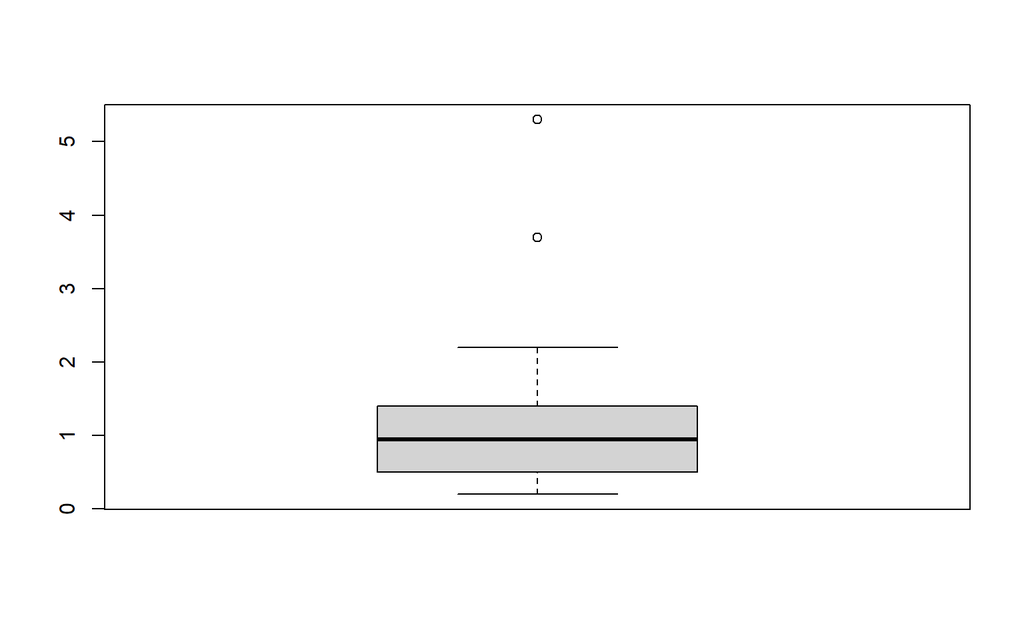

```r
boxplot(data$Y)
```

```r
summary(data$X1)
```

```
##    Min. 1st Qu.  Median    Mean 3rd Qu.    Max.
##   24.79   52.73   65.11   60.72   71.25   84.50
```

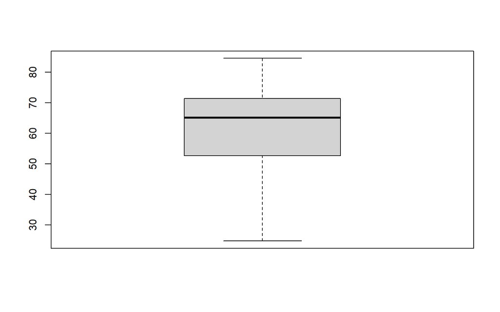

```r
boxplot(data$X1)
```

# Pembentukan Model

## Manual

### Koefisien Regresi

```r
x <- data$X1
y <- data$Y
```

```r
b1 <- (sum(x*y)-sum(x)*sum(y)/n)/(sum(x^2)-(sum(x)^2/n))
b0 <- mean(y)-b1*mean(x)

cat("Koefisien b0:", b0, "\n")
```

```
## Koefisien b0: 2.008968
```

```r
cat("Koefisien b1:", b1, "\n")
```

```
## Koefisien b1: -0.01436251
```

### Standar Error Parameter Regresi

Standar error menunjukan seberapa besar ketidakpastian dalam estimasi koefisien

```r
galat <- y-(b0+b1*x)
ragam_galat <- sum(galat^2)/(n-2)

se_b0 <- sqrt(ragam_galat*(1/n+mean(x)^2/sum((x-mean(x))^2)))
se_b1 <- sqrt(ragam_galat/sum((x-mean(x))^2))

cat("Standar error b0:", se_b0, "\n")
```

```
## Standar error b0: 0.670634
```

```r
cat("Standar error b1:", se_b1, "\n")
```

```
## Standar error b1: 0.01075425
```

### Signifikansi Parameter (nilai-t)

Nilai ini menunjukkan tingkat signifikansi secara parsial dari setiap koefisien peubah berdasarkan nilai t dan probabilitas nilai p

```r
t_b0 <- b0/se_b0
t_b1 <- b1/se_b1
p_b0 <- 2*pt(-abs(t_b0 ),df<-n-2)
p_b1 <- 2*pt(-abs(t_b1 ),df<-n-2)

cat("Nilai t pada b0 adalah", t_b0, "dengan nilai p sebesar", p_b0, "\n")
```

```
## Nilai t pada b0 adalah 2.995624 dengan nilai p sebesar 0.004933273
```

```r
cat("Nilai t pada b1 adalah", t_b1, "dengan nilai p sebesar", p_b1, "\n")
```

```
## Nilai t pada b1 adalah -1.335519 dengan nilai p sebesar 0.1900895
```

Nilai p kurang dari alpha 0.05 untuk b0 sehingga signifikan pada taraf nyata 5% sedangkan untuk b1 lebih dari 0.05 sehingga tidak signifikan

### Koefisien Determinasi dan Penyesuaiannya

Pada analisis regresi linier sederhana, koefisien determinasi yang digunakan adalah multiple R Squared, sedangkan regresi linier berganda menggunakan adjusted R Squared yang disesuaikan dengan banyaknya peubah

```r
r <- (sum(x*y)-sum(x)*sum(y)/n)/
sqrt((sum(x^2)-(sum(x)^2/n))*(sum(y^2)-(sum(y)^2/n)))
Koef_det <- r^2
Koef_det
```

```
## [1] 0.04720597
```

```r
Adj_R2 <- 1-((1-Koef_det)*(n-1)/(n-1-1))
Adj_R2
```

```
## [1] 0.02073947
```

### Signifikansi Simultan (F)

Nilai ini menunjukkan signifikansi dan kebaikan model secara simultan (bersamaan seluruh peubah) yang menjelaskan model secara keseluruhan memiliki hubungan berarti antara X dan Y

```r
galat<-y-(b0+b1*x)

JKG <- sum((y - (b0+b1*x))^2)
JKReg <- sum(((b0+b1*x)- mean(y))^2)
JKT <- sum((y - mean(y))^2)
JKT <- JKReg+JKG

dbReg <- 1
dbg <- n-2
dbt <- n-1

(Fhit <- (JKReg/dbReg)/(JKG/dbg))
```

```
## [1] 1.783612
```

```r
(p_Fhit <- 1-pf(Fhit, dbReg, dbg, lower.tail = F))
```

```
## [1] 0.8099105
```

Nilai p lebih dari alpha 0.05 sehingga secara simultan X dan Y tidak saling memengaruhi

## Menggunakan Fungsi `lm()`

Dalam penggunaan fungsi `lm()`, kita akan memperoleh secara langsung nilai-nilai pada pemodelan regresi dari data yang kita miliki. Hanya dengan mengeluarkan summary dan anova dari model yang terbentuk maka dapat diperoleh nilai parameter, signifikansinya, standar eror, koefisien determinasi hingga ukuran keragamannya.

```r
model <- lm(Y~X1, data = data)
summary(model)
```

```
##
## Call:
## lm(formula = Y ~ X1, data = data)
##
## Residuals:
##     Min      1Q  Median      3Q     Max
## -1.1622 -0.5838 -0.1011  0.2243  3.7322
##
## Coefficients:
##             Estimate Std. Error t value Pr(>|t|)
## (Intercept)  2.00897    0.67063   2.996  0.00493 **
## X1          -0.01436    0.01075  -1.336  0.19009
## ---
## Signif. codes:  0 '***' 0.001 '**' 0.01 '*' 0.05 '.' 0.1 ' ' 1
##
## Residual standard error: 0.9412 on 36 degrees of freedom
## Multiple R-squared:  0.04721,    Adjusted R-squared:  0.02074
## F-statistic: 1.784 on 1 and 36 DF,  p-value: 0.1901
```

```r
anova(model)
```

```
## Analysis of Variance Table
##
## Response: Y
##           Df Sum Sq Mean Sq F value Pr(>F)
## X1         1  1.580 1.57991  1.7836 0.1901
## Residuals 36 31.889 0.88579
```

# Kesimpulan

Model yang terbentuk adalah sebagai berikut:

$$\hat{Y} = 2.00897 - 0.01436
X_1$$

dengan Y adalah Prevalensi Balita Pneumonia dan X1 adalah Persentase Anak Umur 12-23 Bulan yang Menerima Imunisasi Dasar Lengkap.

Nilai $\hat\beta_1 = - 0.01436$ artinya nilai dugaan perubahan dugaan rataan Prevalensi Balita Pneumonia jika Persentase Anak Umur 12-23 Bulan yang Menerima Imunisasi Dasar Lengkap berubah satu tahun adalah sebesar -0.01436%